# Part I - The Loan Original Amount For Borrowers And Its Interactions With Some Other Loan Features

### Exploration_B2

#### Question:

> What is the relationship between the Loan Original Amount and the Loan Original Quarter?

#### Visualization:

```python
#print(df.LoanOriginationQuarter.value_counts())

df_clean.LoanOriginationQuarter.dtypes
```

```
dtype('O')
```

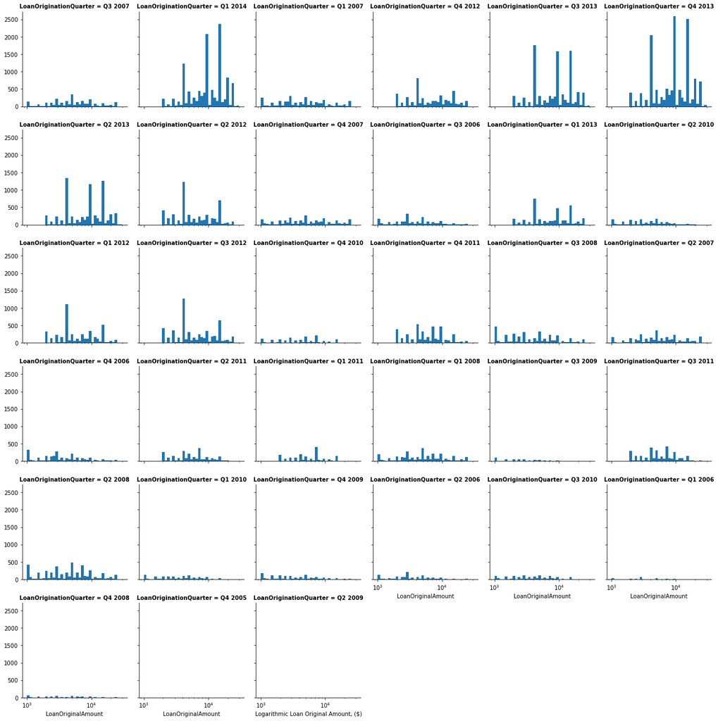

```python
# Faceting would be most fitting to reveal the relationship between the Original Loan Amount and the Loan Status.
# The x-axis is scale tranformed from linear to logarithmic

plt.figure(figsize =(12, 8))

bins1 = 10**np.arange(3, 4.5+0.01, 0.04);

# Plot the Seaborn's FacetGrid
g = sb.FacetGrid(data = df_clean, col = 'LoanOriginationQuarter', col_wrap = 6)
g.map(plt.hist, "LoanOriginalAmount", bins = bins1)

plt.xlabel('Logarithmic Loan Original Amount, ($)')

plt.xscale('log');

plt.show()
```

### Exploration_B3

#### Question:

> How does Loan Original Amount relate with Monthly Loan Payment?

#### Visualization:

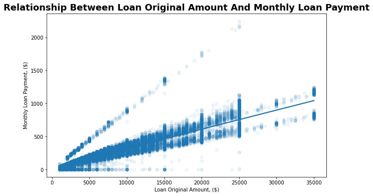

```
0.9313717788802254
```

```python
# This visualization reveals the relationship between the variables OriginalLoanAmount and Loan Payment.
# With both variables being quantitative, a scatter plot is best suited to investigate their interaction

plt.figure(figsize =(10, 6))
sb.regplot(data = df_clean, x='LoanOriginalAmount', y='MonthlyLoanPayment', scatter_kws={'alpha':1/15})
plt.xlabel("Loan Original Amount, ($)")
plt.ylabel("Monthly Loan Payment, ($)")
plt.title("Relationship Between Loan Original Amount And Monthly Loan Payment")

plt.show()

print(df_clean['LoanOriginalAmount'].corr(df_clean['MonthlyLoanPayment']))
```

#### Observation:

> There is a strong positive correlation between the loan original amount and the monthly loan payment the regression line makes obvious and as the correlation value of 0.9313 indicates. The monthly loan payment turned to increase with increasing loan original amount. This phenomenon is more pronounced for monthly loan payments less than 1000 dollars for the range of loan original amount between 0 and 35000 dollars.

### Exploration_B4

#### Question:

> How does the Prosper Score impacts the Loan Original Amount?

#### Visualization:

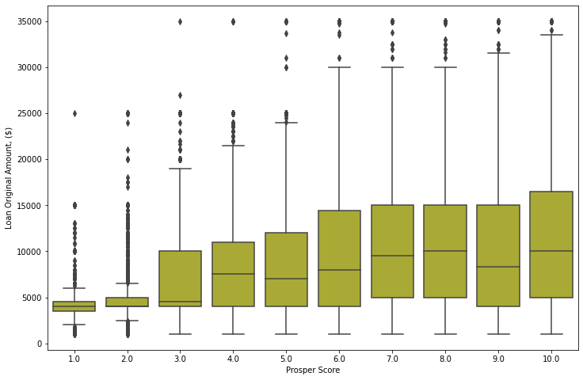

```python
# With Prosper Score being a qualitative variable and the Loan Original Amount a quantitative variable,
# Box plot is appropriate to understand their interactions and effect of each other

base1_color = sb.color_palette()[8]
prosper_score = [1.0, 2.0, 3.0, 4.0, 5.0, 6.0, 7.0, 8.0, 9.0, 10.0]

# Converting the ProsperScore from float datatype to categorical datatype,and in orderedness
# Refer - https://pandas.pydata.org/pandas-docs/version/0.23.4/generated/pandas.api.types.CategoricalDtype.html
pscore = pd.api.types.CategoricalDtype(ordered=True, categories=prosper_score)
df_clean['ProsperScore'] = df_clean['ProsperScore'].astype(pscore);

plt.figure(figsize = (12, 8))
sb.boxplot(data= df_clean, x='ProsperScore', y='LoanOriginalAmount', color=base1_color)
plt.xlabel('Prosper Score')
plt.ylabel('Loan Original Amount, ($)')
plt.xticks(rotation=0);
```

#### Observation:

> The highest risk Prosper Score 1.0 has the lowest median loan original amount, as well as one of the levels of the risk score with a lot of outliers too. The Prosper Scores 8.0 and 10.0 have about the same median loan original amounts, which are also the highest median values. The Prosper score 10.0 has the maximum loan amount, and as expected the Prosper score 1.0 has the least maximum loam amount. The median loan original amount of all other levels of Prosper Score are between those of risk score 1.0 and 8.0 or 1.0 and 10.0.

### Exploration_B5

#### Question:

> What effect does the ownership of a home by a borrower have on the Loan Original Amount?

#### Visualization:

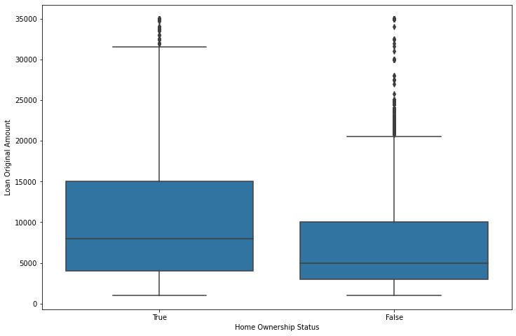

```python
# With IsBorrowerHomeowner being a qualitative variable and the Loan Original Amount a quantitative variable,
# Box plot is appropriate to understand their interactions and effect of each other


home_ownership = [True, False]

# Converting the IsBorrowerHomeowner from bool datatype to categorical datatype,and in orderedness
# Refer - https://pandas.pydata.org/pandas-docs/version/0.23.4/generated/pandas.api.types.CategoricalDtype.html
home_owner = pd.api.types.CategoricalDtype(ordered=True, categories=home_ownership)
df_clean['IsBorrowerHomeowner'] = df_clean['IsBorrowerHomeowner'].astype(home_owner);

plt.figure(figsize = (12, 8))
sb.boxplot(data= df_clean, x='IsBorrowerHomeowner', y='LoanOriginalAmount', color=base_color)
plt.xlabel('Home Ownership Status')
plt.ylabel('Loan Original Amount')
plt.xticks(rotation=0);
```

#### Observation:

> The loan original amount and the home ownership status of the borrowers are related to the extent that the median of the borrowers with homes is greater than those without homes. Apart from this, the first quartile, third quartile and maximum value for home owners are also greater than those without homes. The latter even tend to have a lot of outliers.

### Exploration_B6

#### Question:

> How does the employment status of a borrower influence their Loan Original Amount?

#### Visualization:

```python
print(df_clean['EmploymentStatus'].value_counts())

df_clean.EmploymentStatus.dtypes
```

```
Employed         65957
Full-time        26341
Self-employed     6091
Not available     5347
Other             3772
Part-time         1088
Not employed       835
Retired            795
Name: EmploymentStatus, dtype: int64
```

```
dtype('O')
```

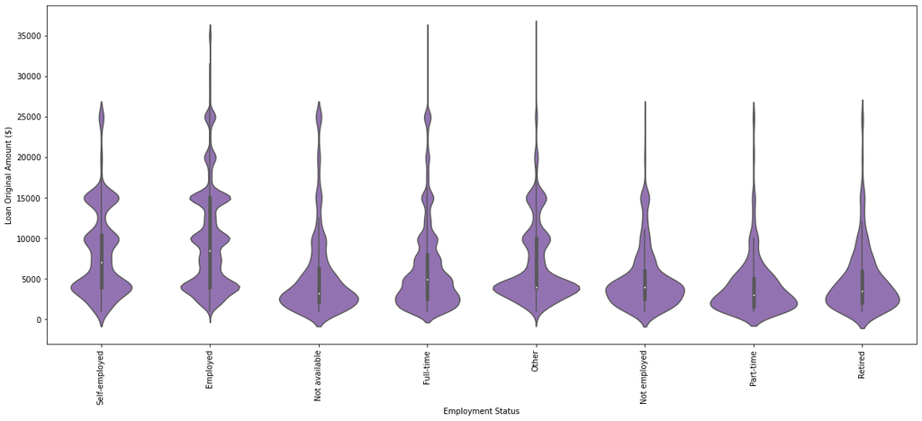

```python
base_color = sb.color_palette()[4]

vplots(df_clean, 'EmploymentStatus','LoanOriginalAmount', base_color)

plt.xticks(rotation=90)
plt.xlabel('Employment Status')
plt.ylabel('Loan Original Amount ($)');
```